# EDA_IMDB_Horror_Genre

```r
# Install Libraries and once packages are installed comment out

#install.packages("tidyverse")
#install.packages("rvest")
#install.packages("corrplot")
```

```r
library(dplyr)
```

```r
library(ggplot2)
library(stringr)
library(tidyr)
```

# .csv file created from IMDBwebscraper

Data for genre has lots of different categories other than horror, even though I chose the horror genre specifically when scraping IMDB.

The Horror genre can be mashed well with all the other movie categories .

```r
# Read the CSV file into a dataframe
df <- read.csv("all_horror_movies_info.csv")

# View the first few rows of the dataframe to verify the data
head(df)
```

|  | name | year | genre | length | user_rating | director | synopsis |
| --- | --- | --- | --- | --- | --- | --- | --- |
| 1 | Alien | (1979) | Horror, Sci-Fi | 117 min | 8.5 | Ridley Scott | The crew of a commercial spacecraft encounters a deadly lifeform after investigating an unknown transmission. |
| 2 | Psycho | (1960) | Horror, Mystery, Thriller | 109 min | 8.5 | Alfred Hitchcock | A Phoenix secretary embezzles $40,000 from her employer's client, goes on the run and checks into a remote motel run by a young man under the domination of his mother. |
| 3 | The Shining | (1980) | Drama, Horror | 146 min | 8.4 | Stanley Kubrick | A family heads to an isolated hotel for the winter where a sinister presence influences the father into violence, while his psychic son sees horrific forebodings from both past and future. |
| 4 | The Thing | (1982) | Horror, Mystery, Sci-Fi | 109 min | 8.2 | John Carpenter | A research team in Antarctica is hunted by a shape-shifting alien that assumes the appearance of its victims. |
| 5 | Tumbbad | (2018) | Drama, Fantasy, Horror | 104 min | 8.2 | Rahi Anil Barve | A mythological story about a goddess who created the entire universe. The plot revolves around the consequences when humans build a temple for her first-born. |
| 6 | The Exorcist | (1973) | Horror | 122 min | 8.1 | William Friedkin | When a young girl is possessed by a mysterious entity, her mother seeks the help of two Catholic priests to save her life. |

# Data Cleaning:

Ensure that your data is clean and properly formatted. Convert variables to appropriate data types, clean up column names, and deal with any missing values.

```r
# Convert year, length, and user_rating to numeric
df <- df %>%
  mutate(year = as.numeric(str_extract(year, "\\d{4}")),
         length = as.numeric(str_extract(length, "\\d+")),
         user_rating = as.numeric(user_rating))

# Remove unnecessary characters from the name and genre columns
df <- df %>%
  mutate(name = str_trim(gsub("\\(.*\\)", "", name)),
         genre = str_trim(genre))
```

# Summary Statistics:

Get an overview of your data with summary statistics.

I find the range of the length of the movies interesting because a great movie can be short or long or right in between.

Interesting thing is the user ratings 3rd quarter to Max deviations are greater than the other quarters.

Also a highly IMDB rated horror movie hasn’t come out since 2018

```r
summary(df)
```

```
##      name                year         genre               length
##  Length:50          Min.   :1920   Length:50          Min.   : 64.00
##  Class :character   1st Qu.:1961   Class :character   1st Qu.: 90.25
##  Mode  :character   Median :1980   Mode  :character   Median :103.00
##                     Mean   :1980                      Mean   :103.86
##                     3rd Qu.:2004                      3rd Qu.:113.75
##                     Max.   :2018                      Max.   :191.00
##   user_rating      director           synopsis
##  Min.   :7.500   Length:50          Length:50
##  1st Qu.:7.600   Class :character   Class :character
##  Median :7.650   Mode  :character   Mode  :character
##  Mean   :7.758
##  3rd Qu.:7.875
##  Max.   :8.500
```

# Histogram of User Ratings:

Horror genre is averaging an IMDB rating 7.8

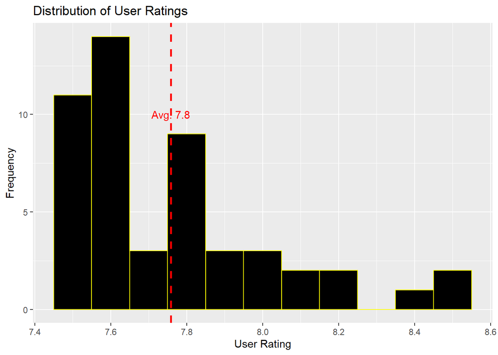

```r
# Calculate the average user rating
avg_rating <- mean(df$user_rating)

# Create the histogram with the average rating marked
ggplot(df, aes(x = user_rating)) +
  geom_histogram(binwidth = 0.1, fill = "black", color = "yellow") +
  geom_vline(xintercept = avg_rating, color = "red", linetype = "dashed", size = 1) +  # Add a vertical line
  annotate("text", x = avg_rating, y = 10, label = paste("Avg:", round(avg_rating, 1)), color = "red") +  # Add text annotation
  labs(title = "Distribution of User Ratings", x = "User Rating", y = "Frequency")
```

# Bar Plot of Movie Counts by Director:

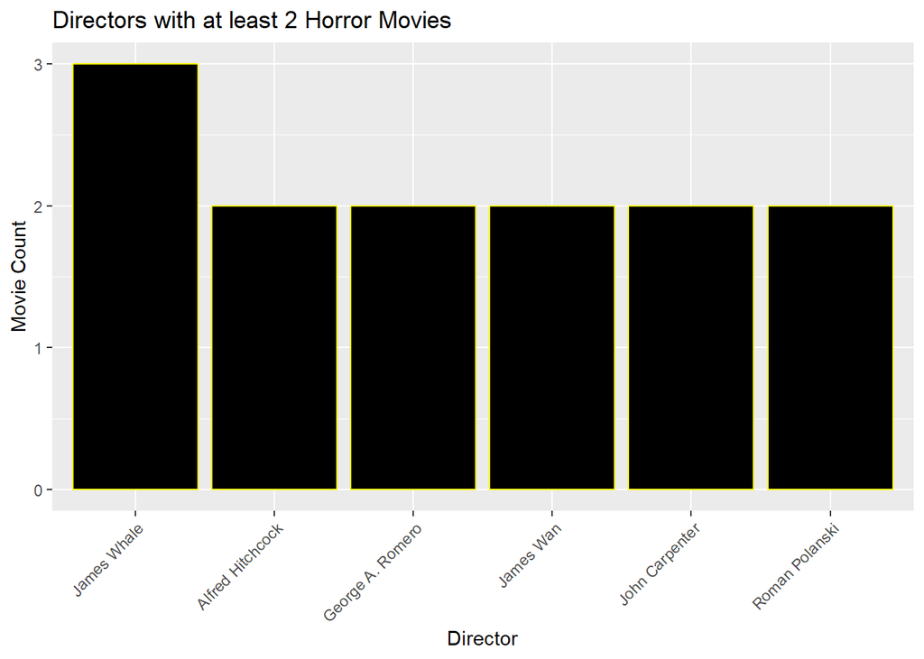

```r
df %>%
  group_by(director) %>%
  summarize(movie_count = n()) %>%
  filter(movie_count >= 2) %>%  # Filter for directors with 2 or more movies
  arrange(desc(movie_count)) %>%
  top_n(10) %>%  # Select the top 10 directors
  ggplot(aes(x = reorder(director, -movie_count), y = movie_count)) +
  geom_bar(stat = "identity", fill = "black", color = "yellow") +
  labs(title = "Directors with at least 2 Horror Movies", x = "Director", y = "Movie Count") +
  theme(axis.text.x = element_text(angle = 45, hjust = 1))
```

# Most Horror Movies made that made the IMDB ratings top were directed by James Whale:

James Whale was an English film director, theatre director and actor. He is best remembered for his four classic horror films: Frankenstein (1931), The Old Dark House (1932), The Invisible Man (1933) and The Bride of Frankenstein (1935). He also directed films in other genres, including what is considered the definitive film version of the musical Show Boat (1936).

Wonder how many other horror movies each of these directors made and if they where rated high on IMDB?

```r
# Filter for directors with 2 or more movies
top_directors <- df %>%
  group_by(director) %>%
  summarize(movie_count = n()) %>%
  filter(movie_count >= 2) %>%
  arrange(desc(movie_count))

# Filter the original dataset to include only movies directed by these directors
filtered_df <- df %>%
  filter(director %in% top_directors$director)

# Print directors and their movies
for (director_name in unique(filtered_df$director)) {
  cat("Director:", director_name, "\n")
  movies_by_director <- filtered_df %>% filter(director == director_name)
  cat("Movies:", paste(movies_by_director$name, collapse = ", "), "\n")
  cat("\n")
}
```

```
## Director: Alfred Hitchcock
## Movies: Psycho, The Birds
##
## Director: John Carpenter
## Movies: The Thing, Halloween
##
## Director: Roman Polanski
## Movies: Rosemary's Baby, Repulsion
##
## Director: George A. Romero
## Movies: Night of the Living Dead, Dawn of the Dead
##
## Director: James Whale
## Movies: Frankenstein, The Bride of Frankenstein, The Invisible Man
##
## Director: James Wan
## Movies: Saw, The Conjuring
```

# Bar chart of Most Common Sub-category within Horror Movies

Horror Drama genre is the most common of the horror movies that are rated high. Animated Horror genre is the least common of the horror movies.

Does Horror Drama movies make the best rated horror movie?

```r
# Explore the structure of the dataset
str(df)
```

```
## 'data.frame':    50 obs. of  7 variables:
##  $ name       : chr  "Alien" "Psycho" "The Shining" "The Thing" ...
##  $ year       : num  1979 1960 1980 1982 2018 ...
##  $ genre      : chr  "Horror, Sci-Fi" "Horror, Mystery, Thriller" "Drama, Horror" "Horror, Mystery, Sci-Fi" ...
##  $ length     : num  117 109 146 109 104 122 117 137 134 67 ...
##  $ user_rating: num  8.5 8.5 8.4 8.2 8.2 8.1 8.1 8 8 8 ...
##  $ director   : chr  "Ridley Scott" "Alfred Hitchcock" "Stanley Kubrick" "John Carpenter" ...
##  $ synopsis   : chr  " The crew of a commercial spacecraft encounters a deadly lifeform after investigating an unknown transmission." " A Phoenix secretary embezzles $40,000 from her employer's client, goes on the run and checks into a remote mot"| __truncated__ " A family heads to an isolated ho…
```

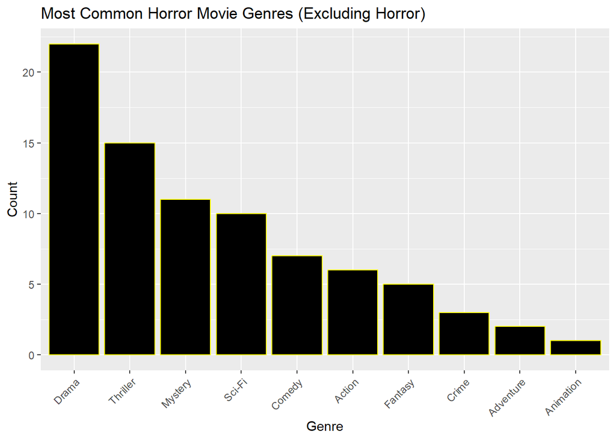

```r
# Create a bar chart for the most common genres, excluding "Horror"
df$genre <- trimws(df$genre)  # Remove leading/trailing white spaces
genres <- unlist(strsplit(df$genre, ", "))

# Remove "Horror" from the list of genres
genres <- genres[genres != "Horror"]

genre_counts <- data.frame(genre = genres) %>%
  group_by(genre) %>%
  summarize(count = n()) %>%
  arrange(desc(count))

ggplot(genre_counts, aes(x = reorder(genre, -count), y = count)) +
  geom_bar(stat = "identity", fill = "black", color = "yellow") +
  labs(title = "Most Common Horror Movie Genres (Excluding Horror)",
       x = "Genre",
       y = "Count") +
  theme(axis.text.x = element_text(angle = 45, hjust = 1))
```

# Time Series line chart to isolate at what year were these great horror movies were made

I can see where James Whales Directed his classic horror movies and there was a group of great ones directed in the late 60’s to ealry 70’s and another push in the late 90’s.

What year would have been the best for a director to make a horror movie?

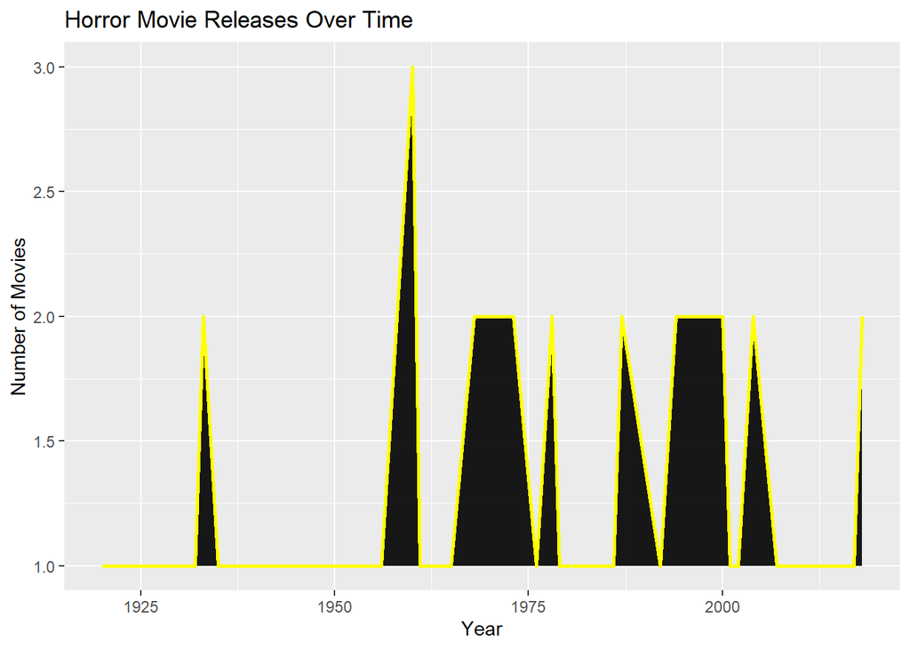

```r
# Filter out rows with missing "year" values
df_filtered <- df[!is.na(df$year),]

# Create a summary of movie counts by year
movie_counts_by_year <- df_filtered %>%
  group_by(year) %>%
  summarize(count = n())

# Filter out years with a count less than 1
movie_counts_by_year <- movie_counts_by_year %>%
  filter(count >= 1)

# Create the line plot with yellow area underneath the curve
ggplot(movie_counts_by_year, aes(x = year, y = count)) +
  geom_ribbon(aes(ymin = 1, ymax = count), fill = "black", alpha = 0.9) +
  geom_line(color = "yellow", size = 1) +
  labs(title = "Horror Movie Releases Over Time",
       x = "Year",
       y = "Number of Movies")
```

# Box plot to show horror movie length by top 5 sub genres

This plot is interesting becausing its showing that Horror Drama movies have the longest duration.

Does movie durations affect user_ratings?

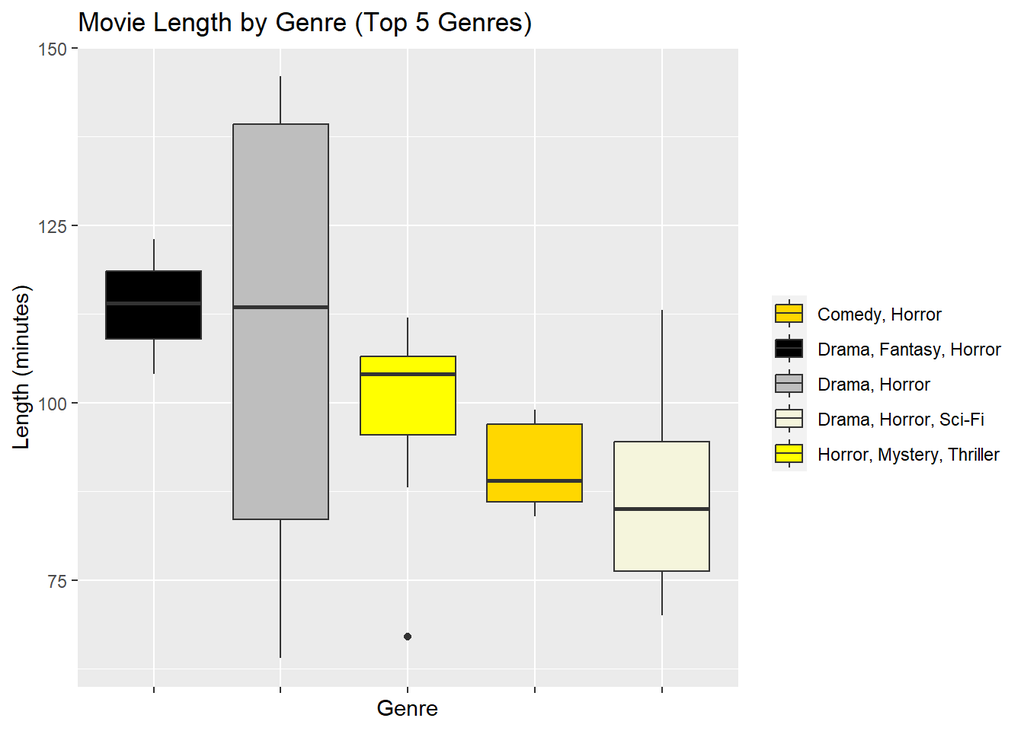

```r
# Set the number of top genres to display
top_n_genres <- 5

# Create a summary of movie counts by genre
genre_counts <- df %>%
  group_by(genre) %>%
  summarize(count = n()) %>%
  arrange(desc(count))

# Select the top N genres by count
top_genres <- head(genre_counts$genre, n = top_n_genres)

# Filter the dataset to include only the top N genres
df_filtered <- df[df$genre %in% top_genres,]

# Create a manual color palette for the top genres
color_palette <- c("gold", "black", "grey", "beige", "yellow")  # Add more colors as needed

# Create a box plot for movie length by genre
ggplot(df_filtered, aes(x = reorder(genre, -length), y = as.numeric(gsub(" min", "", length)), fill = genre)) +
  geom_boxplot() +
  labs(title = "Movie Length by Genre (Top 5 Genres)",
       x = "Genre",
       y = "Length (minutes)",
       fill = "") +
  scale_fill_manual(values = color_palette) +
  theme(axis.text.x = element_blank())  # Remove x-axis labels
```